# 04_Results

Hamza

10/02/2020

### Research Questions

1. Is there a difference in learning abilities across our four F1 conditions (Maternal, Paternal, Within Control & Within Treatment) ?
2. If so, which group is considered the ‘smartest’ (strong learners) and which group is considered the ‘dumbest’ (weak learners) ?

### Hypotheses

F1 fish whose parents were not exposed to a high fat diet (HFD) will be the strongest learners, while F1 fish whose BOTH parents were exposed, will be the weakest. Maternal tanks shouls also display weak learning, as there is plenty of evidence in the literature that maternal HFD result in cognitive impairment in offspring. We assessed learning by observing the difference between the baseline period (before conditioning with the electric shock) and the probe period (after the conditioning) for the conditioned stimulus (blue colour). The less time spent in the blue colour during the probe period indicates the fish learnt to associate that colour with the shock and actively avoid it. The ‘smartest’ fish would therefore have the highest baseline-probe difference.

### Notes

I controlled for days, as well as time of day. Tanks were also pseudorandomized.

### Exploratory Data Analysis

```
##               Tank rating.mean
## 1         Maternal    9.859190
## 2         Paternal    9.687938
## 3   Within_Control    7.449316
## 4 Within_Treatment    5.314190
```

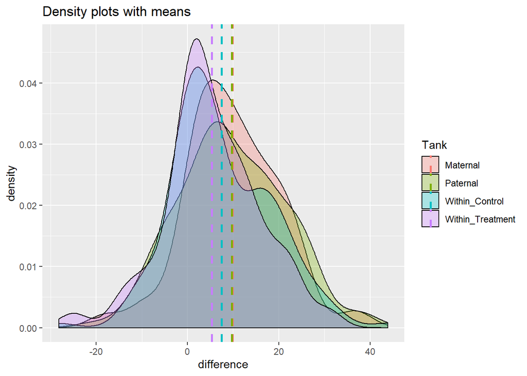

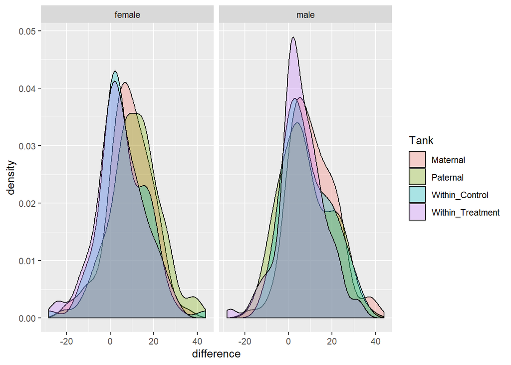

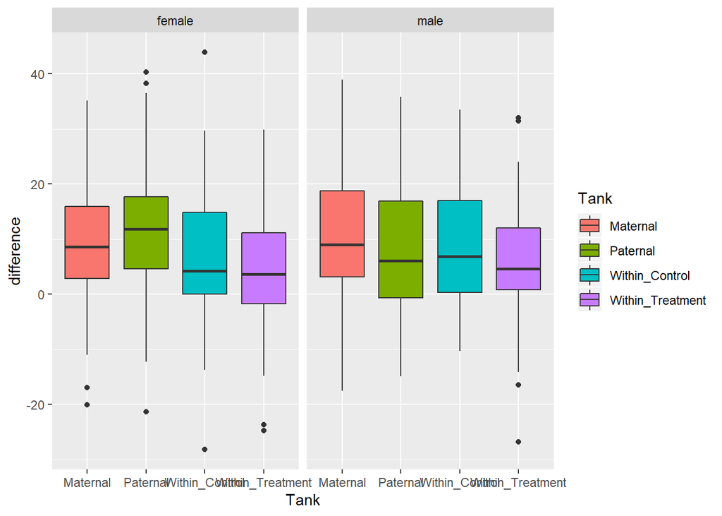

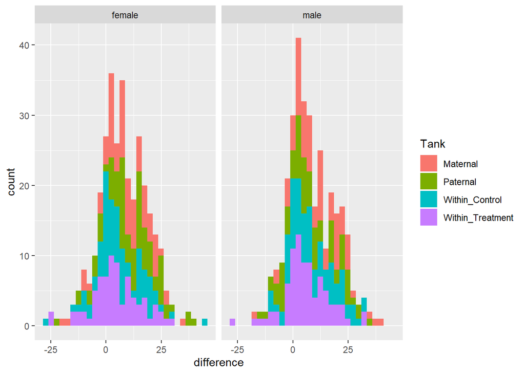

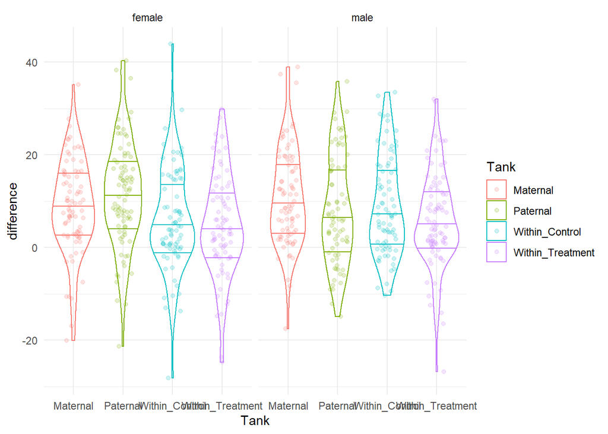

### Mixed Models

Using all of the baseline data, and then the first 2 mins of the probe data (baseline data has been standardized). I also created contrasts to examine whether or not there are differences between certain conditons themselves.

NOTES:

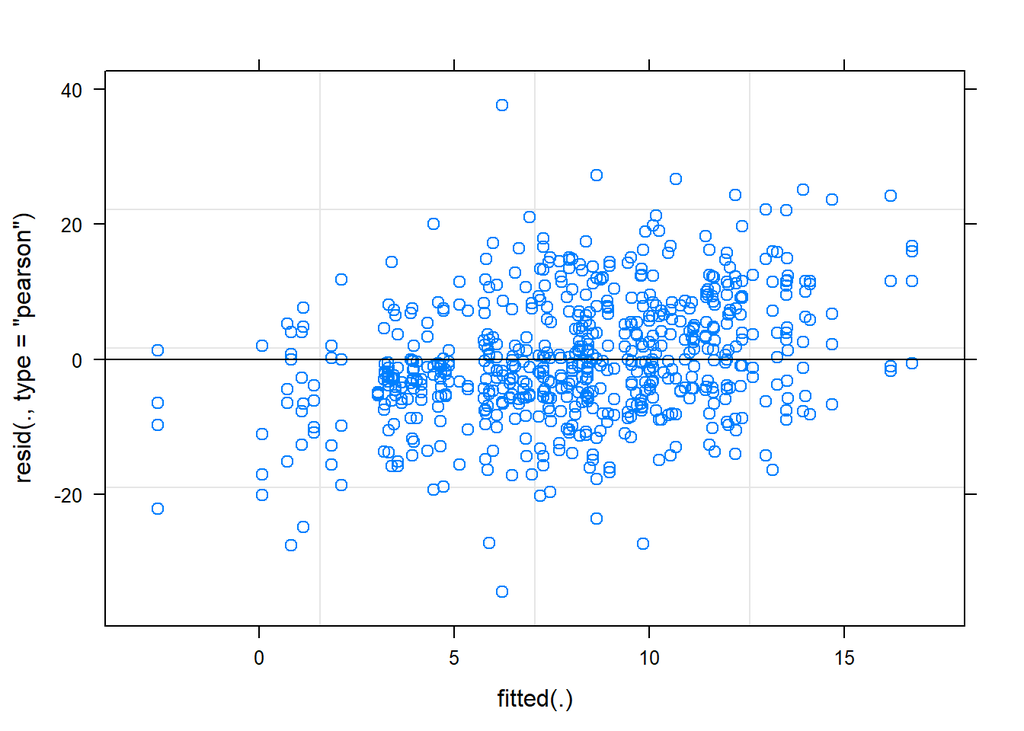

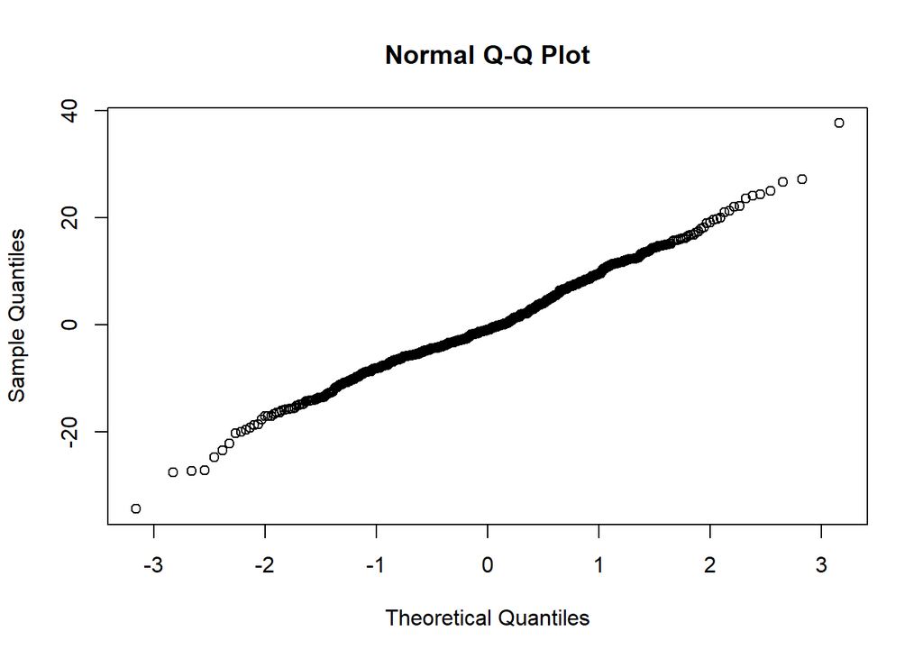

```
## Linear mixed model fit by REML. t-tests use Satterthwaite's method [
## lmerModLmerTest]
## Formula: difference ~ Tank + sex + (1 | fishID)
##    Data: p2cs
##
## REML criterion at convergence: 4819.2
##
## Scaled residuals:
##     Min      1Q  Median      3Q     Max
## -3.4940 -0.5709 -0.1009  0.6555  3.8173
##
## Random effects:
##  Groups   Name        Variance Std.Dev.
##  fishID   (Intercept) 20.01    4.473
##  Residual             97.14    9.856
## Number of obs: 639, groups:  fishID, 164
##
## Fixed effects:
##                      Estimate Std. Error       df t value Pr(>|t|)
## (Intercept)            9.5952     1.1761 155.8193   8.158 1.06e-13 ***
## TankPaternal          -0.1937     1.4856 158.7645  -0.130  0.89643
## TankWithin_Control    -2.3632     1.4862 156.5805  -1.590  0.11382
## TankWithin_Treatment  -4.5760     1.4863 156.6179  -3.079  0.00246 **
## sexmale                0.5279     1.0505 158.4754   0.503  0.61598
## ---
## Signif. codes:  0 '***' 0.001 '**' 0.01 '*' 0.05 '.' 0.1 ' ' 1
##
## Correlation of Fixed Effects:
##             (Intr) TnkPtr TnkW_C TnkW_T
## TankPaternl -0.643
## TnkWthn_Cnt -0.634  0.502
## TnkWthn_Trt -0.627  0.501  0.501
## sexmale     -0.447  0.020  0.002 -0.016
```

|  | difference |  |  |
| --- | --- | --- | --- |
| Predictors | Estimates | CI | p |
| (Intercept) | 9.60 | 7.29 – 11.90 | **<0.001** |
| TankPaternal | -0.19 | -3.11 – 2.72 | 0.896 |
| TankWithin_Control | -2.36 | -5.28 – 0.55 | 0.114 |
| TankWithin_Treatment | -4.58 | -7.49 – -1.66 | **0.002** |
| sexmale | 0.53 | -1.53 – 2.59 | 0.616 |
| Random Effects |  |  |  |
| σ<sup>2</sup> | 97.14 |  |  |
| τ<sub>00</sub> <sub>fishID</sub> | 20.01 |  |  |
| ICC <sub>fishID</sub> | 0.17 |  |  |
| Observations | 639 |  |  |
| Marginal R<sup>2</sup> / Conditional R<sup>2</sup> | 0.029 / 0.195 |  |  |

### Contrasts - overall model

```
##  contrast                          estimate   SE  df t.ratio p.value
##  Maternal - Paternal                  0.194 1.49 158 0.130   0.9992
##  Maternal - Within_Control            2.363 1.49 156 1.590   0.3873
##  Maternal - Within_Treatment          4.576 1.49 156 3.079   0.0130
##  Paternal - Within_Control            2.170 1.48 159 1.462   0.4627
##  Paternal - Within_Treatment          4.382 1.48 159 2.952   0.0188
##  Within_Control - Within_Treatment    2.213 1.48 157 1.491   0.4456
##
## Results are averaged over the levels of: sex
## Degrees-of-freedom method: kenward-roger
## P value adjustment: tukey method for comparing a family of 4 estimates
```

### Week 1 vs Week 2

I compiled plots to examine the data from the first week and second week, as well as linear models.

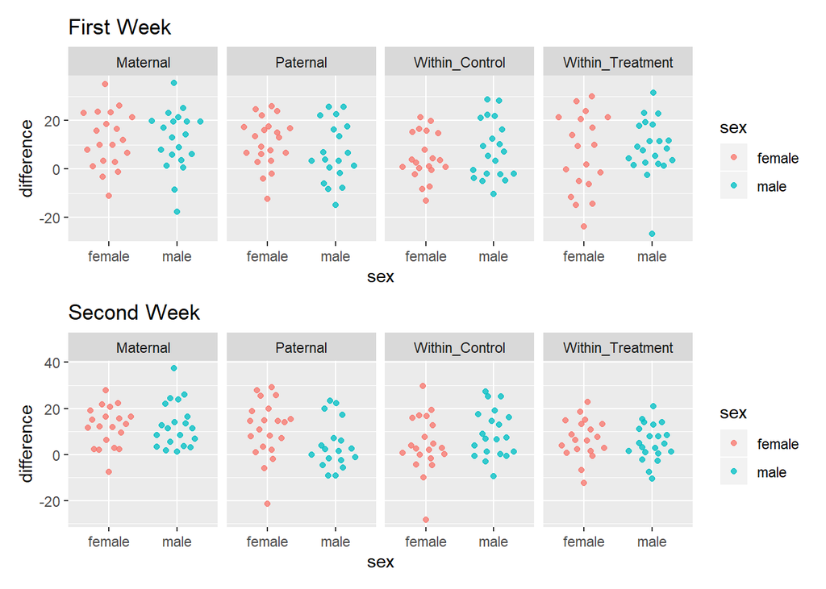

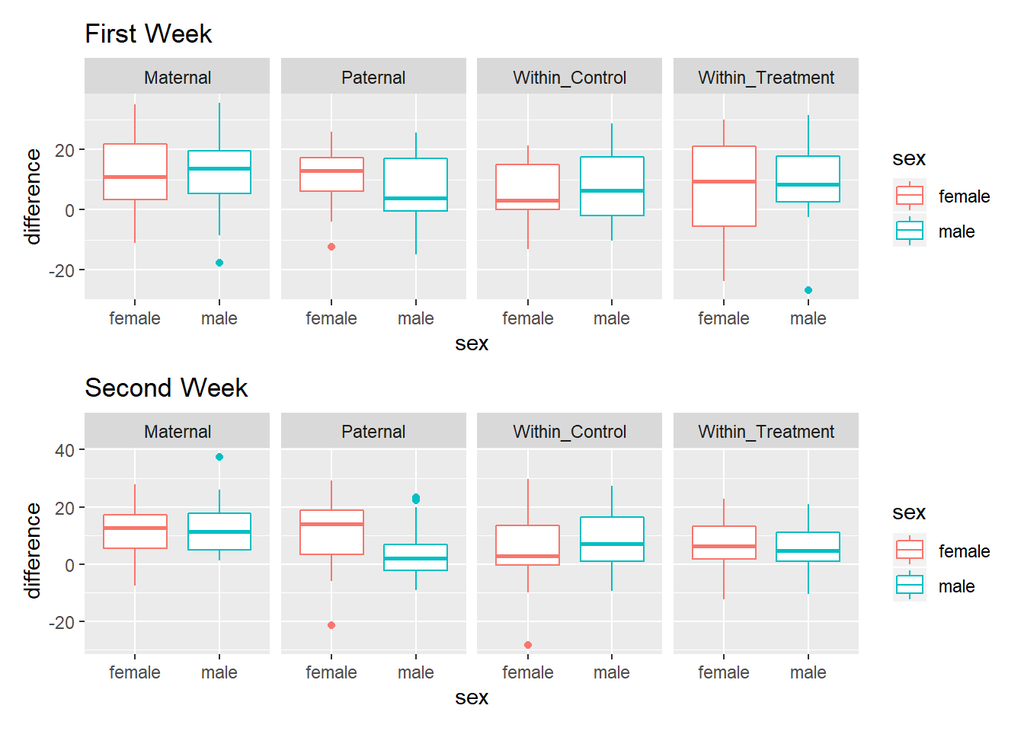

```
##
## Call:
## lm(formula = difference ~ Tank, data = p2cs_half)
##
## Residuals:
##     Min      1Q  Median      3Q     Max
## -34.388  -7.824  -1.128   9.339  23.742
##
## Coefficients:
##                      Estimate Std. Error t value Pr(>|t|)
## (Intercept)            12.007      1.897   6.329  2.5e-09 ***
## TankPaternal           -2.951      2.683  -1.100   0.2731
## TankWithin_Control     -5.604      2.683  -2.089   0.0384 *
## TankWithin_Treatment   -4.367      2.683  -1.627   0.1057
## ---
## Signif. codes:  0 '***' 0.001 '**' 0.01 '*' 0.05 '.' 0.1 ' ' 1
##
## Residual standard error: 12 on 156 degrees of freedom
## Multiple R-squared:  0.03012,    Adjusted R-squared:  0.01147
## F-statistic: 1.615 on 3 and 156 DF,  p-value: 0.1881
```

|  | difference |  |  |
| --- | --- | --- | --- |
| Predictors | Estimates | CI | p |
| (Intercept) | 12.01 | 8.29 – 15.73 | **<0.001** |
| TankPaternal | -2.95 | -8.21 – 2.31 | 0.273 |
| TankWithin_Control | -5.60 | -10.86 – -0.35 | **0.038** |
| TankWithin_Treatment | -4.37 | -9.63 – 0.89 | 0.106 |
| Observations | 160 |  |  |
| R<sup>2</sup> / adjusted R<sup>2</sup> | 0.030 / 0.011 |  |  |

```
##  contrast                          estimate   SE  df t.ratio p.value
##  Maternal - Paternal                   2.95 2.68 156  1.100  0.6902
##  Maternal - Within_Control             5.60 2.68 156  2.089  0.1613
##  Maternal - Within_Treatment           4.37 2.68 156  1.627  0.3662
##  Paternal - Within_Control             2.65 2.68 156  0.989  0.7560
##  Paternal - Within_Treatment           1.42 2.68 156  0.528  0.9522
##  Within_Control - Within_Treatment    -1.24 2.68 156 -0.461  0.9673
##
## P value adjustment: tukey method for comparing a family of 4 estimates
```

```
##
## Call:
## lm(formula = difference ~ Tank + tod, data = p2cs_second_half)
##
## Residuals:
##      Min       1Q   Median       3Q      Max
## -28.3385  -7.0324  -0.2973   6.6332  26.4469
##
## Coefficients:
##                      Estimate Std. Error t value Pr(>|t|)
## (Intercept)           12.8625     1.6003   8.038 2.31e-13 ***
## TankPaternal           1.5674     3.1574   0.496 0.620309
## TankWithin_Control     0.3458     3.1418   0.110 0.912492
## TankWithin_Treatment  -6.4767     2.1337  -3.035 0.002824 **
## todNOON               -2.1662     2.6672  -0.812 0.417949
## todPM                -13.0725     3.4493  -3.790 0.000216 ***
## ---
## Signif. codes:  0 '***' 0.001 '**' 0.01 '*' 0.05 '.' 0.1 ' ' 1
##
## Residual standard error: 9.542 on 153 degrees of freedom
## Multiple R-squared:  0.1934, Adjusted R-squared:  0.1671
## F-statistic: 7.338 on 5 and 153 DF,  p-value: 3.431e-06
```

|  | difference |  |  |
| --- | --- | --- | --- |
| Predictors | Estimates | CI | p |
| (Intercept) | 12.86 | 9.73 – 16.00 | **<0.001** |
| TankPaternal | 1.57 | -4.62 – 7.76 | 0.620 |
| TankWithin_Control | 0.35 | -5.81 – 6.50 | 0.912 |
| TankWithin_Treatment | -6.48 | -10.66 – -2.29 | **0.003** |
| todNOON | -2.17 | -7.39 – 3.06 | 0.418 |
| todPM | -13.07 | -19.83 – -6.31 | **<0.001** |
| Observations | 159 |  |  |
| R<sup>2</sup> / adjusted R<sup>2</sup> | 0.193 / 0.167 |  |  |

```
##  contrast  estimate   SE  df t.ratio p.value
##  AM - NOON     2.17 2.67 153 0.812   0.6961
##  AM - PM      13.07 3.45 153 3.790   0.0006
##  NOON - PM    10.91 2.19 153 4.987   <.0001
##
## Results are averaged over the levels of: Tank
## P value adjustment: tukey method for comparing a family of 3 estimates
```

```
##  contrast                          estimate   SE  df t.ratio p.value
##  Maternal - Paternal                 -1.567 3.16 153 -0.496  0.9598
##  Maternal - Within_Control           -0.346 3.14 153 -0.110  0.9995
##  Maternal - Within_Treatment          6.477 2.13 153  3.035  0.0148
##  Paternal - Within_Control            1.222 2.15 153  0.569  0.9412
##  Paternal - Within_Treatment          8.044 3.16 153  2.548  0.0567
##  Within_Control - Within_Treatment    6.823 3.14 153  2.172  0.1359
##
## Results are averaged over the levels of: tod
## P value adjustment: tukey method for comparing a family of 4 estimates
```

### Third Week

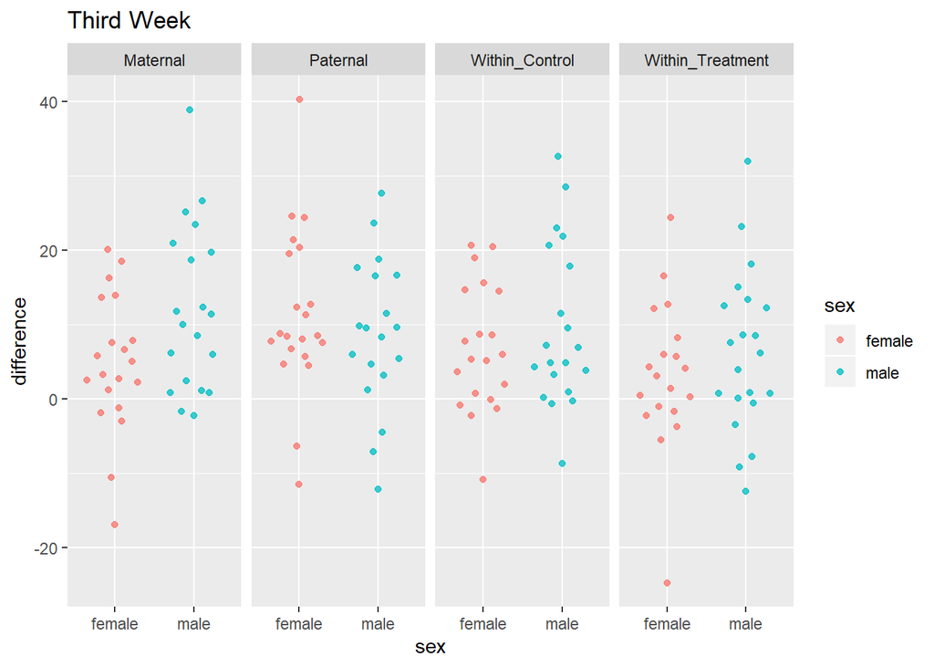

```r
Third_Half <- ggplot(p2cs_third_half, aes(sex, difference, color=sex)) +
  geom_quasirandom(dodge.width=0.01, alpha=0.77)+
facet_grid(~Tank)+
  labs(title = "Third Week")
Third_Half
```

```r
model_third_half <- lm(difference ~ Tank + sex, data = p2cs_third_half)
tab_model(model_third_half)
```

|  | difference |  |  |
| --- | --- | --- | --- |
| Predictors | Estimates | CI | p |
| (Intercept) | 7.05 | 3.45 – 10.65 | **<0.001** |
| TankPaternal | 1.85 | -2.70 – 6.41 | 0.426 |
| TankWithin_Control | -0.12 | -4.68 – 4.43 | 0.957 |
| TankWithin_Treatment | -3.66 | -8.21 – 0.90 | 0.117 |
| sexmale | 2.62 | -0.60 – 5.84 | 0.113 |
| Observations | 160 |  |  |
| R<sup>2</sup> / adjusted R<sup>2</sup> | 0.050 / 0.026 |  |  |

```r
summary(model_third_half)
```

```
##
## Call:
## lm(formula = difference ~ Tank + sex, data = p2cs_third_half)
##
## Residuals:
##     Min      1Q  Median      3Q     Max
## -28.167  -5.970  -1.235   6.979  31.421
##
## Coefficients:
##                      Estimate Std. Error t value Pr(>|t|)
## (Intercept)            7.0501     1.8363   3.839 0.000179 ***
## TankPaternal           1.8530     2.3228   0.798 0.426225
## TankWithin_Control    -0.1246     2.3224  -0.054 0.957295
## TankWithin_Treatment  -3.6573     2.3228  -1.575 0.117404
## sexmale                2.6202     1.6432   1.595 0.112845
## ---
## Signif. codes:  0 '***' 0.001 '**' 0.01 '*' 0.05 '.' 0.1 ' ' 1
##
## Residual standard error: 10.39 on 155 degrees of freedom
## Multiple R-squared:  0.05008,    Adjusted R-squared:  0.02557
## F-statistic: 2.043 on 4 and 155 DF,  p-value: 0.09103
```

```r
contrast_3 <- emmeans(model_third_half, ~Tank)
pairs(contrast_3)
```

```
##  contrast                          estimate   SE  df t.ratio p.value
##  Maternal - Paternal                 -1.853 2.32 155 -0.798  0.8554
##  Maternal - Within_Control            0.125 2.32 155  0.054  0.9999
##  Maternal - Within_Treatment          3.657 2.32 155  1.575  0.3962
##  Paternal - Within_Control            1.978 2.32 155  0.851  0.8297
##  Paternal - Within_Treatment          5.510 2.32 155  2.371  0.0870
##  Within_Control - Within_Treatment    3.533 2.32 155  1.521  0.4275
##
## Results are averaged over the levels of: sex
## P value adjustment: tukey method for comparing a family of 4 estimates
```

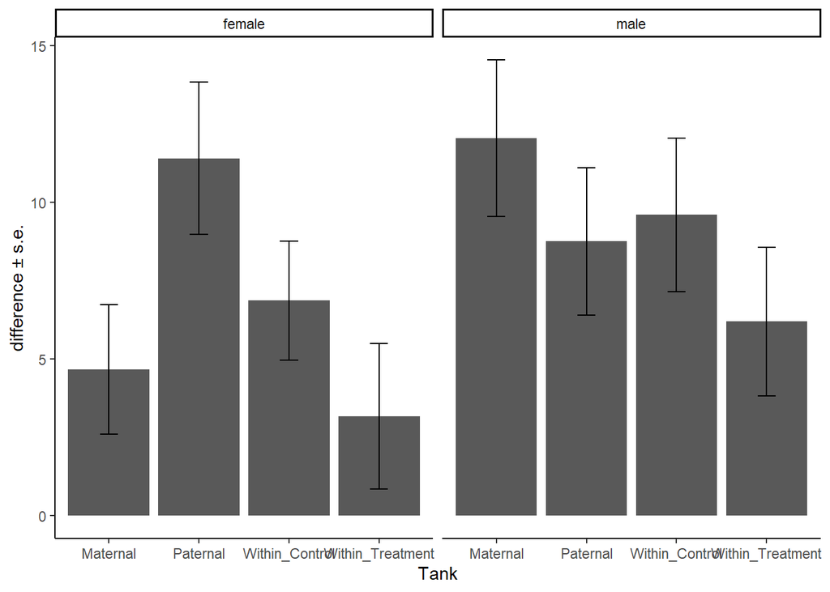

```r
third_week_summary <- p2cs_third_half %>% # the names of the new data frame and the data frame to be summarised
  group_by(sex, Tank) %>%   # the grouping variable
  summarise(mean = mean(difference),  # calculates the mean of each group
            sd = sd(difference), # calculates the standard deviation of each group
            n = n(),  # calculates the sample size per group
            SE = sd(difference)/sqrt(n())) # calculates the standard error of each group

third_week_plot <- ggplot(third_week_summary, aes(Tank, mean)) +
                   geom_col() +
                   geom_errorbar(aes(ymin = mean - SE, ymax = mean + SE), width=0.2)+
  facet_grid(~sex)

third_week_plot + labs(y="difference ± s.e.", x = "Tank") + theme_classic()
```

### Fourth Week

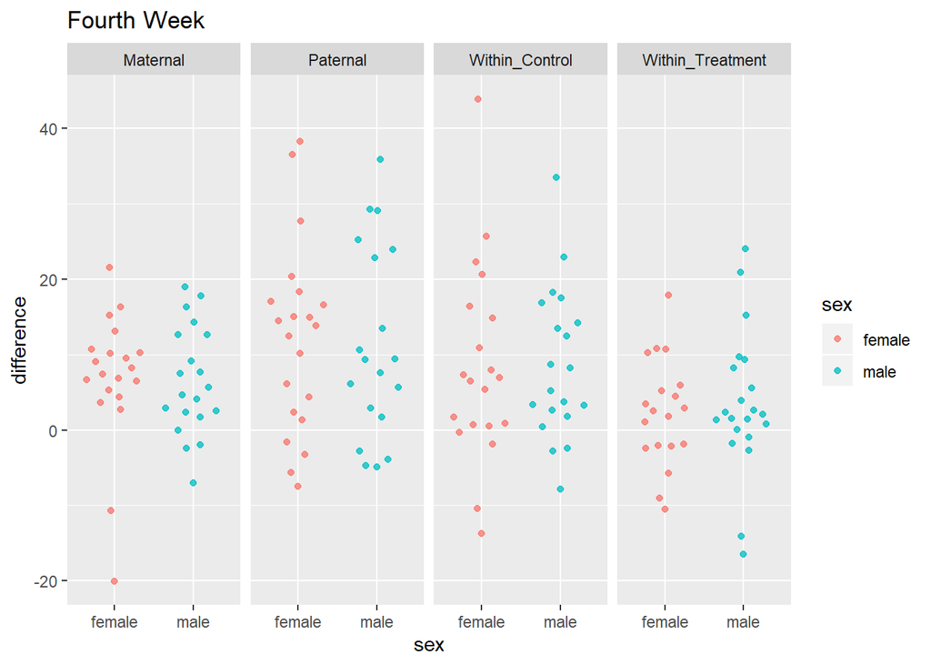

```r
Fourth_Week <- ggplot(p2cs_fourth_week, aes(sex, difference, color=sex)) +
  geom_quasirandom(dodge.width=0.01, alpha=0.77)+
facet_grid(~Tank)+
  labs(title = "Fourth Week")
Fourth_Week
```

```r
model_fourth_week <- lm(difference ~ Tank + sex, data = p2cs_fourth_week)
tab_model(model_fourth_week)
```

|  | difference |  |  |
| --- | --- | --- | --- |
| Predictors | Estimates | CI | p |
| (Intercept) | 6.56 | 2.99 – 10.13 | **<0.001** |
| TankPaternal | 5.07 | 0.56 – 9.59 | **0.029** |
| TankWithin_Control | 1.84 | -2.68 – 6.35 | 0.426 |
| TankWithin_Treatment | -3.75 | -8.26 – 0.77 | 0.106 |
| sexmale | 0.15 | -3.04 – 3.35 | 0.926 |
| Observations | 160 |  |  |
| R<sup>2</sup> / adjusted R<sup>2</sup> | 0.090 / 0.066 |  |  |

```r
summary(model_fourth_week)
```

```
##
## Call:
## lm(formula = difference ~ Tank + sex, data = p2cs_fourth_week)
##
## Residuals:
##     Min      1Q  Median      3Q     Max
## -26.593  -5.657  -0.780   5.894  35.453
##
## Coefficients:
##                      Estimate Std. Error t value Pr(>|t|)
## (Intercept)            6.5640     1.8214   3.604 0.000422 ***
## TankPaternal           5.0746     2.3039   2.203 0.029102 *
## TankWithin_Control     1.8391     2.3036   0.798 0.425869
## TankWithin_Treatment  -3.7483     2.3039  -1.627 0.105784
## sexmale                0.1515     1.6299   0.093 0.926048
## ---
## Signif. codes:  0 '***' 0.001 '**' 0.01 '*' 0.05 '.' 0.1 ' ' 1
##
## Residual standard error: 10.3 on 155 degrees of freedom
## Multiple R-squared:  0.08992,    Adjusted R-squared:  0.06644
## F-statistic: 3.829 on 4 and 155 DF,  p-value: 0.00537
```

```r
contrast_4 <- emmeans(model_fourth_week, ~Tank)
pairs(contrast_4)
```

```
##  contrast                          estimate   SE  df t.ratio p.value
##  Maternal - Paternal                  -5.07 2.30 155 -2.203  0.1271
##  Maternal - Within_Control            -1.84 2.30 155 -0.798  0.8551
##  Maternal - Within_Treatment           3.75 2.30 155  1.627  0.3666
##  Paternal - Within_Control             3.24 2.30 155  1.404  0.4986
##  Paternal - Within_Treatment           8.82 2.31 155  3.828  0.0011
##  Within_Control - Within_Treatment     5.59 2.30 155  2.425  0.0766
##
## Results are averaged over the levels of: sex
## P value adjustment: tukey method for comparing a family of 4 estimates
```